# Solicitudes de crédito: ¿qué determina el monto pedido y quién termina siendo mal pagador?

Trabajo Final — Taller de Pre-procesamiento de Datos · Licenciatura en Ciencia de Datos · Universidad Austral

**Ver código**

```r
library(ggplot2)
library(dplyr)
library(patchwork)
library(VIM)        # kNN
library(car)        # vif
library(MASS)       # stepAIC
library(lmtest)     # bptest, lrtest
library(nortest)    # ad.test
library(boot)       # bootstrap
library(caret)      # createDataPartition, confusionMatrix
library(pROC)       # ROC / AUC
library(ResourceSelection) # hoslem.test

select <- dplyr::select   # MASS enmascara dplyr::select
theme_set(theme_minimal(base_size = 12))
set.seed(2024)
options(OutDec = ",")     # coma decimal en todo el documento (texto y tablas)

# Funciones auxiliares de formato
pv <- function(p) format.pval(p, digits = 2, eps = 0.001)
fmt <- function(x) formatC(x, digits = 3, format = "fg", flag = "#")   # 3 cifras significativas
pct <- function(b) round(100 * (exp(b) - 1), 1)                       # efecto en % de un coeficiente en escala log
f3 <- function(x) formatC(x, digits = 3, format = "f")                # 3 decimales (con coma)

orig <- read.csv("datos/credit_data_original.csv", stringsAsFactors = TRUE)  # datos originales, sin tocar
```

# 1 Introducción

## 1.1 Fuente y contexto

Trabajamos con datos de **solicitudes de crédito de consumo** de una entidad financiera: cada fila es una persona que pidió un préstamo para comprar un bien. Se conoce su perfil (edad, empleo, vivienda, ingresos, deudas), las condiciones del préstamo (monto, plazo, precio del bien) y si el crédito resultó **bueno** o **malo** (mal pagador).

- **Fuente:** base `credit_data` del paquete `modeldata` de R, que proviene del sitio del Dr. Lluís A. Belanche Muñoz (Universitat Politècnica de Catalunya) a través del repositorio de Gaston Sanchez (`github.com/gastonstat/CreditScoring`). No se usó en las clases de la materia.
- **Tamaño:** 4454 solicitantes y 14 variables.
- **Archivos:** `datos/credit_data_original.csv` (sin modificar) y `datos/credit_procesado.rds` (versión procesada).

## 1.2 Objetivos del estudio

1. **Regresión lineal:** entender **de qué depende el monto que pide una persona** (`Amount`): cuánto influyen el precio del bien, el plazo y el perfil del solicitante.
2. **Regresión logística:** **predecir si un solicitante será mal pagador** (`Status = malo`) y saber qué características aumentan o reducen ese riesgo.

## 1.3 Definición de las variables

**Ver código**

```r
dic <- data.frame(
  Variable = c("Status", "Seniority", "Home", "Time", "Age", "Marital", "Records",
               "Job", "Expenses", "Income", "Assets", "Debt", "Amount", "Price"),
  Descripción = c("Resultado del crédito (bad = mal pagador, good = buen pagador)",
                  "Antigüedad en el trabajo actual",
                  "Tipo de vivienda (owner, rent, parents, priv = privada, other, ignore)",
                  "Plazo del préstamo solicitado",
                  "Edad del solicitante",
                  "Estado civil (married, single, divorced, separated, widow)",
                  "Tiene antecedentes registrados (yes/no)",
                  "Tipo de empleo (fixed, freelance, partime, others)",
                  "Gastos del solicitante", "Ingresos del solicitante",
                  "Patrimonio (activos) del solicitante", "Deuda que ya tiene el solicitante",
                  "Monto del préstamo solicitado", "Precio del bien que quiere comprar"),
  Tipo = c("Categórica binaria", "Numérica", "Categórica nominal", "Numérica", "Numérica",
           "Categórica nominal", "Categórica binaria", "Categórica nominal",
           rep("Numérica", 6)),
  Unidad = c("—", "años", "—", "meses", "años", "—", "—", "—", rep("unid. monetarias", 6)),
  Rol = c("Respuesta logística", rep("Predictora", 11), "Respuesta lineal", "Predictora")
)
knitr::kable(dic, caption = "Diccionario de variables (la fuente no informa la moneda: se las llama 'unidades monetarias').")
```

Diccionario de variables (la fuente no informa la moneda: se las llama ‘unidades monetarias’).

| Variable | Descripción | Tipo | Unidad | Rol |
| --- | --- | --- | --- | --- |
| Status | Resultado del crédito (bad = mal pagador, good = buen pagador) | Categórica binaria | — | Respuesta logística |
| Seniority | Antigüedad en el trabajo actual | Numérica | años | Predictora |
| Home | Tipo de vivienda (owner, rent, parents, priv = privada, other, ignore) | Categórica nominal | — | Predictora |
| Time | Plazo del préstamo solicitado | Numérica | meses | Predictora |
| Age | Edad del solicitante | Numérica | años | Predictora |
| Marital | Estado civil (married, single, divorced, separated, widow) | Categórica nominal | — | Predictora |
| Records | Tiene antecedentes registrados (yes/no) | Categórica binaria | — | Predictora |
| Job | Tipo de empleo (fixed, freelance, partime, others) | Categórica nominal | — | Predictora |
| Expenses | Gastos del solicitante | Numérica | unid. monetarias | Predictora |
| Income | Ingresos del solicitante | Numérica | unid. monetarias | Predictora |
| Assets | Patrimonio (activos) del solicitante | Numérica | unid. monetarias | Predictora |
| Debt | Deuda que ya tiene el solicitante | Numérica | unid. monetarias | Predictora |
| Amount | Monto del préstamo solicitado | Numérica | unid. monetarias | Respuesta lineal |
| Price | Precio del bien que quiere comprar | Numérica | unid. monetarias | Predictora |

Hay dos respuestas (`Amount`, cuantitativa, y `Status`, categórica) y 12 posibles predictoras: 4 categóricas y 8 numéricas. Más adelante se agregan variables derivadas (`Ingreso_faltante`, `Pct_fin`, `Tiene_deuda`).

## 1.4 Esquema del análisis

Para no mezclar información del conjunto de prueba con el de entrenamiento, trabajamos con tres versiones de los datos:

- **`base`:** datos originales con las categorías recodificadas, todavía con sus faltantes.
- **`cred`:** `base` con los faltantes imputados usando **todas** las filas. Se usa para el exploratorio y la **regresión lineal**, que no tiene partición en entrenamiento y prueba.
- **`train` / `test`:** para la **regresión logística**, `base` se parte en 75 % / 25 % **antes de imputar**; cada parte se imputa por separado (ver sección de logística).

# 2 Pre-procesamiento

Revisamos la calidad de los datos y tomamos decisiones sobre las seis técnicas de la consigna. Empezamos por recodificar las categorías porque la imputación de faltantes funciona mejor con categorías ya agrupadas.

## 2.1 Revisión inicial

**Ver código**

```r
str(orig)
```

```
'data.frame':   4454 obs. of  14 variables:
 $ Status   : Factor w/ 2 levels "bad","good": 2 2 1 2 2 2 2 2 2 1 ...
 $ Seniority: int  9 17 10 0 0 1 29 9 0 0 ...
 $ Home     : Factor w/ 6 levels "ignore","other",..: 6 6 3 6 6 3 3 4 3 4 ...
 $ Time     : int  60 60 36 60 36 60 60 12 60 48 ...
 $ Age      : int  30 58 46 24 26 36 44 27 32 41 ...
 $ Marital  : Factor w/ 5 levels "divorced","married",..: 2 5 2 4 4 2 2 4 2 2 ...
 $ Records  : Factor w/ 2 levels "no","yes": 1 1 2 1 1 1 1 1 1 1 ...
 $ Job      : Factor w/ 4 levels "fixed","freelance",..: 2 1 2 1 1 1 1 1 2 4 ...
 $ Expenses : int  73 48 90 63 46 75 75 35 90 90 ...
 $ Income   : int  129 131 200 182 107 214 125 80 107 80 ...
 $ Assets   : int  0 0 3000 2500 0 3500 10000 0 15000 0 ...
 $ Debt     : int  0 0 0 0 0 0 0 0 0 0 ...
 $ Amount   : int  800 1000 2000 900 310 650 1600 200 1200 1200 ...
 $ Price    : int  846 1658 2985 1325 910 1645 1800 1093 1957 1468 ...
```

**Ver código**

```r
n_na_filas <- sum(!complete.cases(orig))
```

Hay 415 filas (9,3 %) con al menos un dato faltante. Control de coherencia: solicitantes que piden **más** que el precio del bien: 0; con antigüedad laboral mayor a (edad − 14): 0. Ambos son cero: los datos son coherentes. Que `Amount` esté acotado por `Price` tendrá consecuencias en el modelado.

## 2.2 Recodificación de categorías

**Ver código**

```r
table(Home = orig$Home); table(Marital = orig$Marital); table(Job = orig$Job)
```

```
Home
 ignore   other   owner parents    priv    rent
     20     319    2107     783     246     973
```

```
Marital
 divorced   married separated    single     widow
       38      3241       130       977        67
```

```
Job
    fixed freelance    others   partime
     2805      1024       171       452
```

Hay categorías con muy pocos casos (`ignore`: 20, `divorced`: 38, `widow`: 67, `separated`: 130): sus coeficientes serían inestables. **Agrupamos:**

- `Home`: `ignore` (sin dato) y `other` se unen en **“otra”**.
- `Marital`: `divorced`, `separated` y `widow` se unen en **“otro”**.
- Se traducen las etiquetas al español y se fija como **categoría de referencia la más frecuente** (propia, casado, empleo fijo): cada coeficiente se interpreta “respecto de” esa categoría. `Status` se define con “malo” como evento de interés.

**Ver código**

```r
base <- orig
base$Home <- factor(case_when(orig$Home == "owner" ~ "propia", orig$Home == "rent" ~ "alquila",
                              orig$Home == "parents" ~ "padres", orig$Home == "priv" ~ "privada",
                              is.na(orig$Home) ~ NA_character_, TRUE ~ "otra"),
                    levels = c("propia", "alquila", "padres", "privada", "otra"))
base$Marital <- factor(case_when(orig$Marital == "married" ~ "casado", orig$Marital == "single" ~ "soltero",
                                 is.na(orig$Marital) ~ NA_character_, TRUE ~ "otro"),
                       levels = c("casado", "soltero", "otro"))
base$Job <- factor(case_when(orig$Job == "fixed" ~ "fijo", orig$Job == "freelance" ~ "independiente",
                             orig$Job == "partime" ~ "medio_tiempo", is.na(orig$Job) ~ NA_character_,
                             TRUE ~ "otro"),
                   levels = c("fijo", "independiente", "medio_tiempo", "otro"))
base$Records <- factor(ifelse(orig$Records == "yes", "si", "no"), levels = c("no", "si"))
base$Status <- factor(ifelse(orig$Status == "bad", "malo", "bueno"), levels = c("bueno", "malo"))
sapply(base[, c("Status", "Home", "Marital", "Records", "Job")],
       function(x) paste(levels(x), table(x), sep = ": ", collapse = " | "))
```

```
                                                                Status
                                            "bueno: 3200 | malo: 1254"
                                                                  Home
"propia: 2107 | alquila: 973 | padres: 783 | privada: 246 | otra: 339"
                                                               Marital
                             "casado: 3241 | soltero: 977 | otro: 235"
                                                               Records
                                                  "no: 3681 | si: 773"
                                                                   Job
    "fijo: 2805 | independiente: 1024 | medio_tiempo: 452 | otro: 171"
```

## 2.3 Tratamiento de datos faltantes

**Ver código**

```r
faltantes <- data.frame(Variable = names(orig), N_faltantes = colSums(is.na(orig)),
                        Porcentaje = round(colSums(is.na(orig)) / nrow(orig) * 100, 2), row.names = NULL)
faltantes <- faltantes[faltantes$N_faltantes > 0, ]
knitr::kable(faltantes, row.names = FALSE, caption = "Variables con datos faltantes")
```

Variables con datos faltantes

| Variable | N_faltantes | Porcentaje |
| --- | --- | --- |
| Home | 6 | 0,13 |
| Marital | 1 | 0,02 |
| Job | 2 | 0,04 |
| Income | 381 | 8,55 |
| Assets | 47 | 1,06 |
| Debt | 18 | 0,40 |

**Ver código**

```r
n_inc <- sum(is.na(orig$Income))
```

Hay faltantes en 6 variables, pero el problema real es `Income` (381 casos, 8,6 %); las demás no superan el 1,1 %.

### 2.3.1 ¿Por qué faltan? Los tres mecanismos (Unidad 6)

| Mecanismo | Idea | Ejemplo con este dataset | Consecuencia |
| --- | --- | --- | --- |
| **MCAR** (*missing completely at random*) | La probabilidad de faltar es la misma para todos; no depende de ninguna variable. | Una falla informática borra al azar el ingreso de algunos formularios. | Usar solo los casos completos no sesga, solo pierde precisión. |
| **MAR** (*missing at random*) | La probabilidad de faltar depende de **otras variables que sí observamos**, no del valor faltante en sí. | El ingreso falta más entre quienes tienen poca antigüedad laboral o ciertos tipos de empleo. | Usar solo casos completos **sesga**; se corrige imputando con las variables observadas. |
| **MNAR** (*missing not at random*) | La probabilidad de faltar depende **del propio valor faltante** (aun considerando lo observado). | Quienes tienen ingresos muy bajos prefieren no informarlos. | No se corrige solo con los datos y **no se puede verificar** a partir de ellos. |

### 2.3.2 Evidencia: ¿es MCAR el faltante de `Income`?

Si fuera MCAR, quienes **no informaron** el ingreso serían “iguales” a los demás en todo lo observado. Definimos `Ingreso_faltante` (1 = ingreso faltante, 0 = observado, **antes** de imputar) y comparamos los dos grupos:

**Ver código**

```r
base$Ingreso_faltante <- as.integer(is.na(base$Income))
fal <- base$Ingreso_faltante == 1
evid <- data.frame(
  Variable = c("Status", "Job", "Records", "Seniority"),
  Medida = c("% mal pagadores", "% con empleo fijo", "% con antecedentes", "Antigüedad (mediana, años)"),
  Ingreso_observado = c(100 * mean(base$Status[!fal] == "malo"), 100 * mean(base$Job[!fal] == "fijo", na.rm = TRUE),
                        100 * mean(base$Records[!fal] == "si"), median(base$Seniority[!fal])),
  Ingreso_faltante = c(100 * mean(base$Status[fal] == "malo"), 100 * mean(base$Job[fal] == "fijo", na.rm = TRUE),
                       100 * mean(base$Records[fal] == "si"), median(base$Seniority[fal])))
evid[, 3:4] <- round(evid[, 3:4], 1)
knitr::kable(evid, caption = "Ingreso faltante vs. observado")
```

Ingreso faltante vs. observado

| Variable | Medida | Ingreso_observado | Ingreso_faltante |
| --- | --- | --- | --- |
| Status | % mal pagadores | 25,5 | 57,0 |
| Job | % con empleo fijo | 68,0 | 9,2 |
| Records | % con antecedentes | 16,4 | 27,8 |
| Seniority | Antigüedad (mediana, años) | 5,0 | 3,0 |

Además, con la herramienta de la Unidad 5: una **regresión logística simple** con `Ingreso_faltante` como respuesta y `Status` como predictora, comparada con el **modelo nulo** (solo el intercepto) mediante el **test de razón de verosimilitud** (`lrtest`). Si fuera MCAR, `Status` no ayudaría a predecir si el ingreso falta:

**Ver código**

```r
lr_status <- lrtest(glm(Ingreso_faltante ~ 1, family = binomial, data = base),
                    glm(Ingreso_faltante ~ Status, family = binomial, data = base))
lr_status
```

|  | #Df | LogLik | Df | Chisq | Pr(>Chisq) |
| --- | --- | --- | --- | --- | --- |
| 1 | 1 | -1301,006 | NA | NA | NA |
| 2 | 2 | -1224,672 | 1 | 152,6682 | 4,526674e-35 |

El p-valor es <0,001: `Status` sí ayuda a explicar la ausencia del ingreso. Entre quienes no informan ingreso, el 57 % es mal pagador (contra el 25,5 % de quienes lo informan), solo el 9,2 % tiene empleo fijo (contra el 68 %), el 27,8 % tiene antecedentes (contra el 16,4 %) y tienen menos antigüedad (mediana 3 vs. 5 años). Por lo tanto:

- **No es MCAR:** la ausencia del ingreso está relacionada con otras variables.
- **Es plausible que sea MAR**, porque la ausencia se asocia a variables que sí observamos (resultado del crédito, tipo de empleo, antecedentes, antigüedad).
- **MNAR no puede descartarse ni verificarse con estos datos** (por ejemplo, si los ingresos muy bajos se ocultan más). Lo declaramos como limitación.

### 2.3.3 Decisiones

1. **No eliminar los casos incompletos.** Bajo MAR, trabajar solo con casos completos **sesga** las estimaciones (se vio en la Unidad 6 con datos simulados) y además se perdería el 9,3 % de las filas, justamente un grupo de mayor riesgo.
2. **No usar media/mediana:** asigna el mismo valor a todos, subestima la variabilidad y supone MCAR.
3. **Imputar con kNN** (`VIM::kNN`, k = 5): cada faltante se completa con los valores de los 5 solicitantes más parecidos según las variables completas (antigüedad, edad, plazo, gastos, precio, antecedentes). Bajo MAR el faltante depende de variables observadas, así que buscar vecinos por esas variables es lo adecuado; además imputa numéricas y categóricas a la vez. **No se usan `Status` ni `Amount`** para medir la cercanía, para no meter la respuesta en las predictoras. (`mice`, imputación múltiple, es otra alternativa válida; no se implementó.)
4. **Conservar la información de que el ingreso faltaba:** como la ausencia está asociada al riesgo, usamos **`Ingreso_faltante`** como candidata en ambos modelos; la selección de variables decide si aporta.

**Ver código**

```r
vars_con_na <- c("Income", "Assets", "Debt", "Home", "Marital", "Job")
vars_dist <- c("Seniority", "Age", "Time", "Expenses", "Price", "Records")  # solo variables completas

imputar_knn <- function(d) kNN(d, variable = vars_con_na, k = 5, dist_var = vars_dist, imp_var = FALSE)

# Imputa un conjunto "test" usando SOLO filas de train como donantes: cada fila de test con faltantes
# se agrega sola al train ya imputado, así sus únicos vecinos posibles son filas de train.
imputar_con_train <- function(test_raw, train_imp) {
  out <- test_raw
  for (i in which(!complete.cases(test_raw[vars_con_na]))) {
    comb <- rbind(train_imp[names(test_raw)], test_raw[i, ])
    comb <- kNN(comb, variable = vars_con_na, k = 5, dist_var = vars_dist, imp_var = FALSE)
    out[i, ] <- comb[nrow(comb), ]
  }
  out
}

set.seed(2024)
cred <- imputar_knn(base)    # imputación con todas las filas: para el exploratorio y la regresión lineal
cat("Faltantes luego de imputar:", sum(is.na(cred)), "\n")
```

```
Faltantes luego de imputar: 0
```

**Ver código**

```r
# ¿Cómo quedó el ingreso imputado?
comp <- rbind(
  data.frame(Income = base$Income[!fal], Grupo = "Observados"),
  data.frame(Income = cred$Income[fal], Grupo = "Imputados (kNN)"),
  data.frame(Income = rep(median(base$Income, na.rm = TRUE), sum(fal)), Grupo = "Imputados (mediana)"))
comp$Grupo <- factor(comp$Grupo, levels = c("Observados", "Imputados (kNN)", "Imputados (mediana)"))
comp |> group_by(Grupo) |>
  summarise(n = n(), Media = round(mean(Income), 1), Desvio = round(sd(Income), 1), Mediana = median(Income),
            Min = min(Income), Max = max(Income)) |>
  knitr::kable(caption = "Ingreso: observados vs. imputados")
```

Ingreso: observados vs. imputados

| Grupo | n | Media | Desvio | Mediana | Min | Max |
| --- | --- | --- | --- | --- | --- | --- |
| Observados | 4073 | 141,7 | 80,7 | 125 | 6 | 959 |
| Imputados (kNN) | 381 | 126,6 | 38,1 | 123 | 45 | 310 |
| Imputados (mediana) | 381 | 125,0 | 0,0 | 125 | 125 | 125 |

La mediana asigna exactamente el mismo valor a los 381 casos (desvío 0). kNN da valores distintos según el perfil de cada persona, pero con **menos dispersión** que los observados (son “medianas de vecinos”): una limitación habitual de la imputación simple.

## 2.4 Creación de variables derivadas

- **`Ingreso_faltante`:** marca a quienes no informaron el ingreso (ya creada).
- **`Pct_fin = 100 * Amount / Price`:** porcentaje del precio del bien que se financia (el resto lo paga el cliente de su bolsillo). No se usa en el modelo lineal porque contiene a la respuesta (`Amount`).
- **`Tiene_deuda`:** si ya tiene alguna deuda (`Debt > 0`). Casi todos tienen deuda 0 y unos pocos valores enormes, así que “tiene / no tiene” es más estable que el monto.

Las definimos como funciones para aplicarlas igual a `cred` y, más adelante, a `train` y `test`:

**Ver código**

```r
derivar <- function(d) {
  d$Pct_fin <- 100 * d$Amount / d$Price
  d$Tiene_deuda <- factor(ifelse(d$Debt > 0, "si", "no"), levels = c("no", "si"))
  d
}
cred <- derivar(cred)
```

## 2.5 Transformaciones de variables

Medimos la asimetría (0 = simétrica; mayor a 1 = muy sesgada a la derecha):

**Ver código**

```r
asim <- function(x) mean((x - mean(x))^3) / sd(x)^3
num <- c("Seniority", "Age", "Time", "Expenses", "Income", "Assets", "Debt", "Amount", "Price")
tab_asim <- data.frame(Variable = num, Asimetria = round(sapply(cred[num], asim), 2),
                       Ceros = sapply(cred[num], function(x) sum(x == 0)), row.names = NULL)
knitr::kable(tab_asim, caption = "Asimetría y cantidad de ceros")
```

Asimetría y cantidad de ceros

| Variable | Asimetria | Ceros |
| --- | --- | --- |
| Seniority | 1,38 | 535 |
| Age | 0,48 | 0 |
| Time | -0,77 | 0 |
| Expenses | 1,01 | 0 |
| Income | 2,67 | 0 |
| Assets | 10,24 | 1634 |
| Debt | 9,37 | 3686 |
| Amount | 1,15 | 0 |
| Price | 3,00 | 0 |

`Income`, `Price` y `Amount` son asimétricas a la derecha (cola larga de valores altos, típico del dinero). `Assets` lo es extremadamente y tiene 1634 ceros. **Decisión:** aplicamos **logaritmo** a `Amount`, `Price` e `Income` porque (i) simetriza y (ii) los efectos del dinero suelen ser proporcionales, lo que permite interpretarlos en **porcentajes**. Para `Assets`, que tiene ceros, usamos **log(1 + x)**. `Debt` ya se resumió en `Tiene_deuda`. `Seniority` también es asimétrica (535 ceros): en la regresión lineal la dejamos en su escala original (su relación con el monto resultó lineal) y usamos `log_Seniority = log(1 + Seniority)` en la logística, donde el diagnóstico de ajuste mostró que su efecto no es lineal (sección 6).

**Ver código**

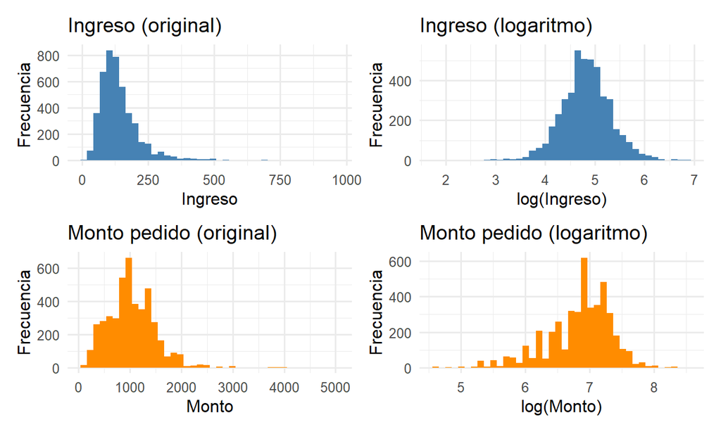

```r
transformar <- function(d) {
  d$log_Amount <- log(d$Amount); d$log_Price <- log(d$Price)
  d$log_Income <- log(d$Income); d$log_Assets <- log1p(d$Assets)
  d$log_Seniority <- log1p(d$Seniority)
  d
}
cred <- transformar(cred)

p1 <- ggplot(cred, aes(Income)) + geom_histogram(bins = 40, fill = "steelblue") +
  labs(title = "Ingreso (original)", x = "Ingreso", y = "Frecuencia")
p2 <- ggplot(cred, aes(log_Income)) + geom_histogram(bins = 40, fill = "steelblue") +
  labs(title = "Ingreso (logaritmo)", x = "log(Ingreso)", y = "Frecuencia")
p3 <- ggplot(cred, aes(Amount)) + geom_histogram(bins = 40, fill = "darkorange") +
  labs(title = "Monto pedido (original)", x = "Monto", y = "Frecuencia")
p4 <- ggplot(cred, aes(log_Amount)) + geom_histogram(bins = 40, fill = "darkorange") +
  labs(title = "Monto pedido (logaritmo)", x = "log(Monto)", y = "Frecuencia")
(p1 | p2) / (p3 | p4)
```

El logaritmo del ingreso queda mucho más simétrico. En el monto aparece una cola hacia la izquierda (montos muy chicos respecto del precio) que retomamos en los supuestos del modelo lineal.

## 2.6 Cambio de escala

No estandarizamos las variables: queremos interpretar los coeficientes en **unidades reales** (años, meses, %), y las comparaciones entre variables se hacen con odds ratios por unidad interpretable (por ejemplo, “duplicar el ingreso” o “10 puntos más financiados”).

## 2.7 Detección y tratamiento de valores atípicos

Usamos la regla del boxplot (valores a más de 1,5 rangos intercuartílicos de los cuartiles):

**Ver código**

```r
n_atip <- function(x) { q <- quantile(x, c(.25, .75)); r <- q[2] - q[1]; sum(x < q[1] - 1.5 * r | x > q[2] + 1.5 * r) }
atip_cmp <- data.frame(Variable = c("Price", "Income", "Assets"),
                       Original = sapply(cred[c("Price", "Income", "Assets")], n_atip),
                       Con_log = c(n_atip(cred$log_Price), n_atip(cred$log_Income), n_atip(cred$log_Assets)),
                       row.names = NULL)
knitr::kable(atip_cmp, caption = "Cantidad de atípicos: variable original vs. su logaritmo")
```

Cantidad de atípicos: variable original vs. su logaritmo

| Variable | Original | Con_log |
| --- | --- | --- |
| Price | 174 | 274 |
| Income | 232 | 101 |
| Assets | 278 | 0 |

**Ver código**

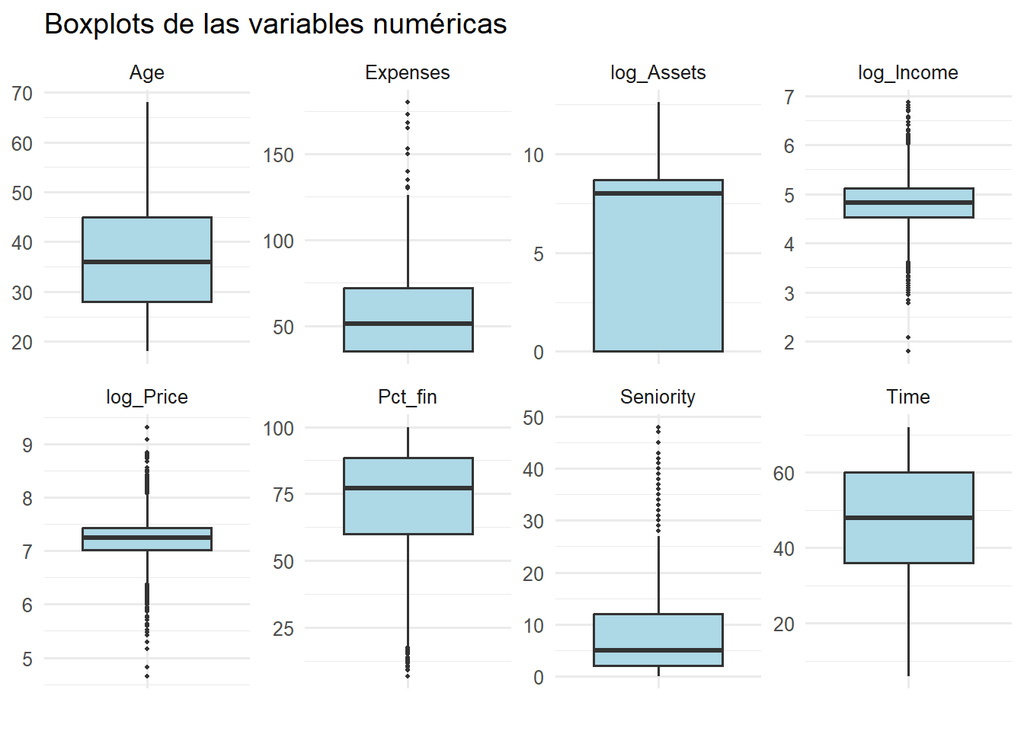

```r
vars_at <- c("Seniority", "Age", "Time", "Expenses", "Pct_fin", "log_Price", "log_Income", "log_Assets")
cred[vars_at] |> tidyr::pivot_longer(everything(), names_to = "Variable", values_to = "Valor") |>
  ggplot(aes(x = "", y = Valor)) + geom_boxplot(fill = "lightblue", outlier.size = .8) +
  facet_wrap(~ Variable, scales = "free_y", nrow = 2) +
  labs(title = "Boxplots de las variables numéricas", x = NULL, y = NULL)
```

**Decisión: no eliminamos ningún caso.** Los extremos (ingresos de hasta 959, un bien de 11140, antigüedades de 48 años) son **plausibles y reales**, no errores de carga; eliminarlos sacaría información justamente de los casos de interés. El logaritmo acerca los valores altos al resto (el ingreso pasa de 232 a 101 atípicos y los activos de 278 a 0, aunque en `Price` aparecen precios bajos como atípicos). Más adelante **evaluamos su influencia** con la distancia de Cook.

**Ver código**

```r
saveRDS(cred, "datos/credit_procesado.rds")
write.csv(cred, "datos/credit_procesado.csv", row.names = FALSE)
```

# 3 Análisis exploratorio

El exploratorio usa `cred` (imputada con todas las filas; es solo descriptivo) y se orienta a los dos objetivos.

**Ver código**

```r
pmalo <- function(v) round(100 * tapply(cred$Status == "malo", cred[[v]], mean))
n_malos_pct <- round(100 * mean(cred$Status == "malo"), 1)
```

## 3.1 Exploración orientada a la regresión lineal (monto pedido)

**Ver código**

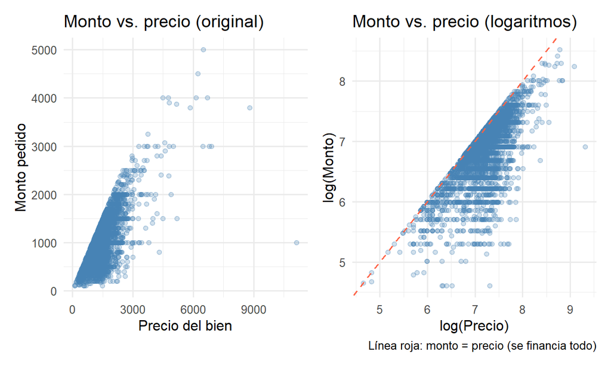

```r
e1 <- ggplot(cred, aes(Price, Amount)) + geom_point(alpha = .25, color = "steelblue") +
  labs(title = "Monto vs. precio (original)", x = "Precio del bien", y = "Monto pedido")
e2 <- ggplot(cred, aes(log_Price, log_Amount)) + geom_point(alpha = .25, color = "steelblue") +
  geom_abline(slope = 1, intercept = 0, color = "tomato", linetype = "dashed") +
  labs(title = "Monto vs. precio (logaritmos)", x = "log(Precio)", y = "log(Monto)",
       caption = "Línea roja: monto = precio (se financia todo)")
e1 | e2
```

El monto crece con el precio (correlación de los logaritmos: 0,71) y **ningún punto supera la línea roja** (monto = precio). Con logaritmos la relación se parece más a una recta.

**Ver código**

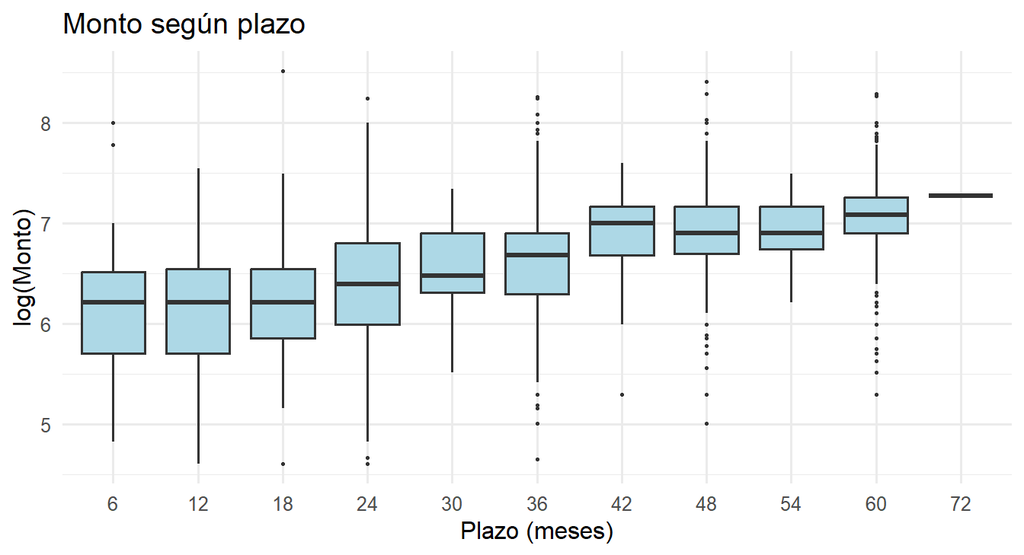

```r
ggplot(cred, aes(factor(Time), log_Amount)) + geom_boxplot(fill = "lightblue", outlier.size = .6) +
  labs(title = "Monto según plazo", x = "Plazo (meses)", y = "log(Monto)")
```

A **mayor plazo, mayor monto** (correlación 0,53), pero el aumento parece desacelerarse en los plazos largos: lo retomamos en el modelo.

## 3.2 Exploración orientada a la regresión logística (mal pagador)

El **28,2 %** de los solicitantes resultó mal pagador: hay eventos suficientes para modelar, aunque las clases están algo desbalanceadas (importará al elegir el punto de corte).

**Ver código**

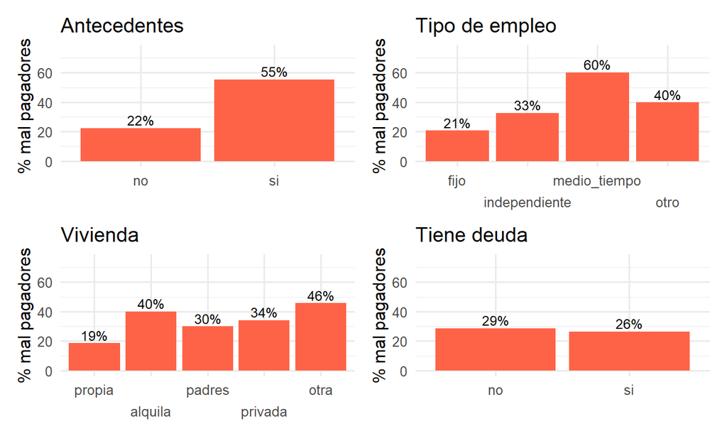

```r
prop_malo <- function(var, titulo, dodge = 1) {
  cred |> group_by(.data[[var]]) |> summarise(Prop_malo = 100 * mean(Status == "malo"), n = n()) |>
    ggplot(aes(.data[[var]], Prop_malo)) + geom_col(fill = "tomato") +
    geom_text(aes(label = paste0(round(Prop_malo), "%")), vjust = -.3, size = 3.3) +
    scale_x_discrete(guide = guide_axis(n.dodge = dodge)) +
    ylim(0, 75) + labs(title = titulo, x = NULL, y = "% mal pagadores")
}
(prop_malo("Records", "Antecedentes") | prop_malo("Job", "Tipo de empleo", 2)) /
  (prop_malo("Home", "Vivienda", 2) | prop_malo("Tiene_deuda", "Tiene deuda"))
```

Con **antecedentes** son mal pagadores el 55 % contra el 22 % sin ellos; los **empleados de medio tiempo** (60 %) e **independientes** (33 %) presentan más riesgo que los de empleo fijo (21 %); los **propietarios** son los de menor riesgo (19 %) frente a 40 % de quienes alquilan. **Tener deuda previa**, en cambio, casi no marca diferencia (26 % vs. 29 %).

**Ver código**

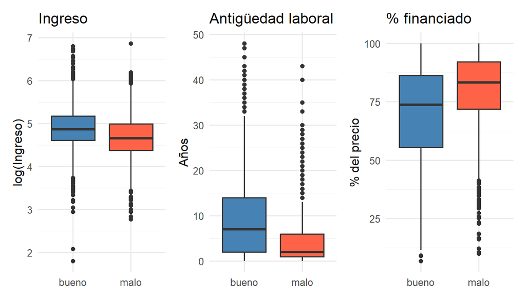

```r
q1 <- ggplot(cred, aes(Status, log_Income, fill = Status)) + geom_boxplot(show.legend = FALSE) +
  scale_fill_manual(values = c("steelblue", "tomato")) + labs(title = "Ingreso", x = NULL, y = "log(Ingreso)")
q2 <- ggplot(cred, aes(Status, Seniority, fill = Status)) + geom_boxplot(show.legend = FALSE) +
  scale_fill_manual(values = c("steelblue", "tomato")) + labs(title = "Antigüedad laboral", x = NULL, y = "Años")
q3 <- ggplot(cred, aes(Status, Pct_fin, fill = Status)) + geom_boxplot(show.legend = FALSE) +
  scale_fill_manual(values = c("steelblue", "tomato")) + labs(title = "% financiado", x = NULL, y = "% del precio")
q1 | q2 | q3
```

Los mal pagadores tienen **menos ingreso**, **menos antigüedad** (mediana 2 vs. 7 años) y **financian un porcentaje mayor** del bien (mediana 83 % vs. 74 %).

**Resumen del exploratorio.** El monto depende sobre todo del precio y del plazo. El riesgo de ser mal pagador se asocia con antecedentes, tipo de empleo, menor ingreso y antigüedad, y mayor porcentaje financiado.

# 4 Regresión lineal: ¿de qué depende el monto pedido?

**Respuesta:** `log_Amount` (logaritmo del monto pedido). **Candidatas a predictoras:** `log_Price`, `Time`, `Seniority`, `Age`, `Marital`, `Records`, `Job`, `Expenses`, `log_Income`, `log_Assets`, `Tiene_deuda`, `Home` e `Ingreso_faltante`. No incluimos `Pct_fin` (contiene a la respuesta) ni `Status` (nos interesa el perfil del solicitante *antes* de saber si pagará). Como la regresión lineal no tiene partición en entrenamiento y prueba, usamos `cred` (imputada con todas las filas); es válido porque la imputación **no usó la respuesta** (`Amount`).

**Ver código**

```r
# AIC y BIC calculados como en stepAIC: criterio = n·log(RSS/n) + k·(cantidad de coeficientes), con k = 2 (AIC) o k = log(n) (BIC).
# Para glm se usa el AIC que muestra summary() (m$aic) ajustado por k. Solo importan las diferencias entre modelos: menor = mejor.
crit_k <- function(m, k) {
  p <- length(coef(m))
  if (inherits(m, "glm")) m$aic + (k - 2) * p else { n <- length(residuals(m)); n * log(sum(residuals(m)^2) / n) + k * p }
}
aic <- function(m) crit_k(m, 2)
bic <- function(m) crit_k(m, log(length(residuals(m))))
resumen <- function(m, nombre) data.frame(Modelo = nombre, Coeficientes = length(coef(m)),
  AIC = round(aic(m), 1), BIC = round(bic(m), 1), R2_ajustado = round(summary(m)$adj.r.squared, 4))
```

## 4.1 Modelo inicial (con todas las predictoras)

**Ver código**

```r
f_full <- log_Amount ~ log_Price + Time + Seniority + Age + Marital + Records + Job +
  Expenses + log_Income + log_Assets + Tiene_deuda + Home + Ingreso_faltante
m_full <- lm(f_full, data = cred)
summary(m_full)
```

```
Call:
lm(formula = f_full, data = cred)

Residuals:
     Min       1Q   Median       3Q      Max
-1,72618 -0,11346  0,05403  0,18439  1,01962

Coefficients:
                   Estimate Std. Error t value Pr(>|t|)
(Intercept)       0,4415785  0,0891312   4,954 7,53e-07 ***
log_Price         0,7362587  0,0115805  63,578  < 2e-16 ***
Time              0,0137989  0,0003233  42,686  < 2e-16 ***
Seniority        -0,0020702  0,0006836  -3,028 0,002474 **
Age               0,0009869  0,0005628   1,754 0,079584 .
Maritalsoltero    0,0471361  0,0146025   3,228 0,001256 **
Maritalotro       0,0219523  0,0210992   1,040 0,298196
Recordssi         0,0377703  0,0120208   3,142 0,001689 **
Jobindependiente  0,0786576  0,0125303   6,277 3,77e-10 ***
Jobmedio_tiempo   0,0539447  0,0159199   3,389 0,000709 ***
Jobotro           0,0305291  0,0255995   1,193 0,233103
Expenses          0,0004366  0,0002879   1,517 0,129431
log_Income        0,0627752  0,0099343   6,319 2,89e-10 ***
log_Assets        0,0057994  0,0018193   3,188 0,001444 **
Tiene_deudasi    -0,0348401  0,0132341  -2,633 0,008503 **
Homealquila       0,0626438  0,0177583   3,528 0,000424 ***
Homepadres        0,0340387  0,0181878   1,872 0,061341 .
Homeprivada       0,0449123  0,0203256   2,210 0,027181 *
Homeotra          0,0736378  0,0211995   3,474 0,000518 ***
Ingreso_faltante  0,0068378  0,0179494   0,381 0,703257
---
Signif. codes:  0 '***' 0,001 '**' 0,01 '*' 0,05 '.' 0,1 ' ' 1

Residual standard error: 0,2989 on 4434 degrees of freedom
Multiple R-squared:  0,6569,    Adjusted R-squared:  0,6555
F-statistic: 446,9 on 19 and 4434 DF,  p-value: < 2,2e-16
```

**Ver código**

```r
vif_full <- vif(m_full)
vif_full
```

```
                     GVIF Df GVIF^(1/(2*Df))
log_Price        1,170625  1        1,081954
Time             1,118403  1        1,057546
Seniority        1,556157  1        1,247460
Age              1,904682  1        1,380102
Marital          1,904051  2        1,174680
Records          1,033000  1        1,016366
Job              1,703821  3        1,092875
Expenses         1,572663  1        1,254059
log_Income       1,192962  1        1,092228
log_Assets       2,935187  1        1,713239
Tiene_deuda      1,245641  1        1,116083
Home             3,975855  4        1,188307
Ingreso_faltante 1,256098  1        1,120758
```

El modelo completo explica el 65,5 % de la variabilidad del log-monto (R² ajustado). Los GVIF ajustados (`GVIF^(1/(2*Df))`) son todos menores a 1,8: **no hay multicolinealidad**. Varias variables tienen efectos pequeños o no significativos (por ejemplo `Age`, `Expenses`, y `Ingreso_faltante` con p = 0,7); la selección de variables decide cuáles quedan.

## 4.2 Selección de variables

Usamos `stepAIC` hacia atrás (*backward*), con AIC y con BIC (`k = log(n)`):

**Ver código**

```r
bwd_aic <- stepAIC(m_full, direction = "backward", trace = 0)
bwd_bic <- stepAIC(m_full, direction = "backward", k = log(nrow(cred)), trace = 0)
rbind(resumen(m_full, "Completo"), resumen(bwd_aic, "Backward (AIC)"), resumen(bwd_bic, "Backward (BIC)")) |>
  knitr::kable(caption = "Selección de variables (AIC y BIC calculados como en stepAIC; solo importan las diferencias, menor es mejor)")
```

Selección de variables (AIC y BIC calculados como en stepAIC; solo importan las diferencias, menor es mejor)

| Modelo | Coeficientes | AIC | BIC | R2_ajustado |
| --- | --- | --- | --- | --- |
| Completo | 20 | -10736,6 | -10608,6 | 0,6555 |
| Backward (AIC) | 19 | -10738,5 | -10616,8 | 0,6555 |
| Backward (BIC) | 10 | -10721,5 | -10657,5 | 0,6535 |

**Ver código**

```r
# Modelo elegido por BIC, escrito explícitamente (se verifica que coincide con el que devolvió stepAIC)
f_bic <- log_Amount ~ log_Price + Time + Seniority + Records + Job + log_Income + Tiene_deuda
n_var <- function(f) length(strsplit(as.character(f)[3], " + ", fixed = TRUE)[[1]])   # cantidad de variables de una fórmula
stopifnot(setequal(names(coef(lm(f_bic, data = cred))), names(coef(bwd_bic))),
          !any(grepl("^(Age|Marital|Expenses|log_Assets|Home|Ingreso_faltante)", names(coef(bwd_bic)))),
          length(coef(bwd_aic)) == length(coef(m_full)) - 1, !("Ingreso_faltante" %in% names(coef(bwd_aic))))
m_bic <- bwd_bic
```

- **AIC** descarta solo `Ingreso_faltante`: penaliza poco y conserva casi todo.
- **BIC** descarta `Age`, `Marital`, `Expenses`, `log_Assets`, `Home` e `Ingreso_faltante`, y deja **7 variables**. Penaliza la complejidad más que el AIC y, con n = 4454, evita incorporar variables de efecto mínimo.
- **`Ingreso_faltante` no entra** en ninguno: en el lineal, no informar el ingreso no se asocia con el monto pedido una vez considerado el resto.

**Decisión:** elegimos el **modelo BIC** por parsimonia: tiene 10 coeficientes frente a 20 y su R² ajustado baja solo de 0,6555 a 0,6535. Pierde casi nada y es mucho más fácil de explicar.

## 4.3 Evaluación de supuestos

**Ver código**

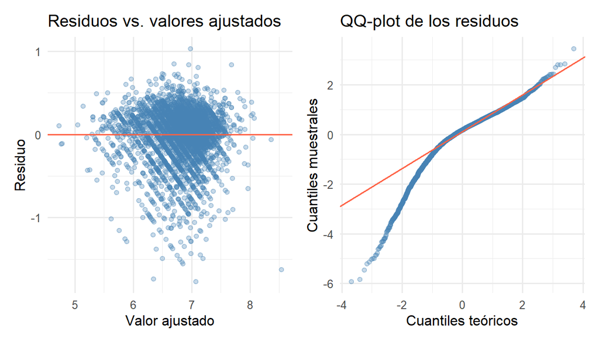

```r
dg <- data.frame(ajustado = fitted.values(m_bic), residuo = residuals(m_bic), rstud = rstudent(m_bic))
g1 <- ggplot(dg, aes(ajustado, residuo)) + geom_point(alpha = .3, color = "steelblue") +
  geom_hline(yintercept = 0, color = "tomato") +
  labs(title = "Residuos vs. valores ajustados", x = "Valor ajustado", y = "Residuo")
g2 <- ggplot(dg, aes(sample = rstud)) + stat_qq(alpha = .3, color = "steelblue") + stat_qq_line(color = "tomato") +
  labs(title = "QQ-plot de los residuos", x = "Cuantiles teóricos", y = "Cuantiles muestrales")
g1 | g2
```

**Ver código**

```r
bp1 <- bptest(m_bic); ad1 <- ad.test(residuals(m_bic)); asim1 <- asim(residuals(m_bic))
bp1
```

```
    studentized Breusch-Pagan test

data:  m_bic
BP = 240,72, df = 9, p-value < 2,2e-16
```

**Ver código**

```r
ad1
```

```
    Anderson-Darling normality test

data:  residuals(m_bic)
A = 105,73, p-value < 2,2e-16
```

**Ver código**

```r
cat("Asimetría de los residuos:", round(asim1, 2), "\n")
```

```
Asimetría de los residuos: -1,44
```

- **Homocedasticidad: no se cumple.** La dispersión de los residuos no es constante (es mayor y más asimétrica en la zona central de valores ajustados, con muchos residuos muy negativos). Las **bandas diagonales** aparecen porque los montos pedidos son valores “redondos” (500, 1000, 1500…) y el monto nunca supera al precio. Breusch-Pagan rechaza (p <0,001).
- **Normalidad: no se cumple.** El QQ-plot se aleja de la recta en la cola izquierda y Anderson-Darling rechaza (p <0,001). La asimetría de los residuos es **negativa y fuerte** (-1,44): hay solicitantes que piden mucho menos de lo esperado.
- **Independencia:** los datos no tienen orden temporal ni agrupamiento, así que **Durbin-Watson no tiene sentido** y no se aplica.
- **Linealidad:** graficamos los residuos contra cada predictora numérica con una curva suavizada (si la relación es lineal, la curva debería ser aproximadamente una recta horizontal en 0):

**Ver código**

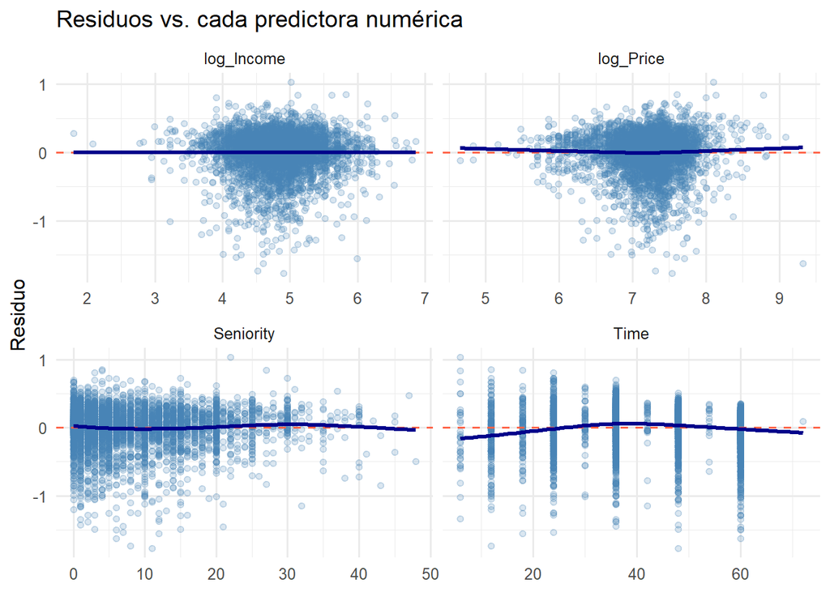

```r
rp <- data.frame(residuo = residuals(m_bic), log_Price = cred$log_Price, Time = cred$Time,
                 Seniority = cred$Seniority, log_Income = cred$log_Income)
rp |> tidyr::pivot_longer(-residuo, names_to = "Predictora", values_to = "valor") |>
  ggplot(aes(valor, residuo)) + geom_point(alpha = .2, color = "steelblue") +
  geom_hline(yintercept = 0, color = "tomato", linetype = "dashed") +
  geom_smooth(se = FALSE, color = "darkblue") +
  facet_wrap(~ Predictora, scales = "free_x") +
  labs(title = "Residuos vs. cada predictora numérica", x = NULL, y = "Residuo")
```

En `Seniority`, `log_Income` y `log_Price` la curva es casi una recta horizontal en 0: la relación es razonablemente lineal. **`Time` muestra curvatura clara**: los residuos tienen forma de “U invertida” (el modelo lineal sobreestima los plazos muy cortos y muy largos y subestima los intermedios): el monto crece con el plazo pero cada vez más lento. Agregamos un **término cuadrático** `I(Time^2)`:

**Ver código**

```r
f_pol <- log_Amount ~ log_Price + Time + I(Time^2) + Seniority + Records + Job + log_Income + Tiene_deuda
m_pol <- lm(f_pol, data = cred)
an_pol <- anova(m_bic, m_pol)
an_pol
```

|  | Res.Df | RSS | Df | Sum of Sq | F | Pr(>F) |
| --- | --- | --- | --- | --- | --- | --- |
| 1 | 4444 | 399,3798 | NA | NA | NA | NA |
| 2 | 4443 | 390,9239 | 1 | 8,455822 | 96,10365 | 1,839245e-22 |

**Ver código**

```r
rbind(resumen(m_bic, "BIC (lineal en Time)"), resumen(m_pol, "BIC + Time al cuadrado")) |> knitr::kable()
```

| Modelo | Coeficientes | AIC | BIC | R2_ajustado |
| --- | --- | --- | --- | --- |
| BIC (lineal en Time) | 10 | -10721,5 | -10657,5 | 0,6535 |
| BIC + Time al cuadrado | 11 | -10814,8 | -10744,4 | 0,6608 |

**Ver código**

```r
bp2 <- bptest(m_pol); ad2 <- ad.test(residuals(m_pol))
```

El término cuadrático es significativo (p <0,001) y mejora AIC y BIC (BIC: -10657 → -10744, una mejora de 87 puntos); lo incorporamos. Corrige la linealidad, pero **la heterocedasticidad (p <0,001) y la no normalidad (p <0,001) persisten**: no es un problema de forma funcional sino de los datos (hay una cola de solicitantes que piden montos muy bajos respecto del precio: financian poco y pagan casi todo de su bolsillo). Se aborda con **bootstrap** (más abajo).

## 4.4 Atípicos e influyentes

**Ver código**

```r
n <- nrow(cred); p <- length(coef(m_pol))
infl <- data.frame(id = 1:n, rstud = rstudent(m_pol), h = hatvalues(m_pol), cook = cooks.distance(m_pol))
tab_infl <- data.frame(Criterio = c("|residuo studentizado| > 3", "Leverage > 2p/n", "Distancia de Cook > 4/n", "Distancia de Cook > 1"),
           Casos = c(sum(abs(infl$rstud) > 3), sum(infl$h > 2 * p / n), sum(infl$cook > 4 / n), sum(infl$cook > 1)))
knitr::kable(tab_infl, caption = "Observaciones atípicas e influyentes")
```

Observaciones atípicas e influyentes

| Criterio | Casos |
| --- | --- |
| \|residuo studentizado\| > 3 | 81 |
| Leverage > 2p/n | 349 |
| Distancia de Cook > 4/n | 260 |
| Distancia de Cook > 1 | 0 |

**Ver código**

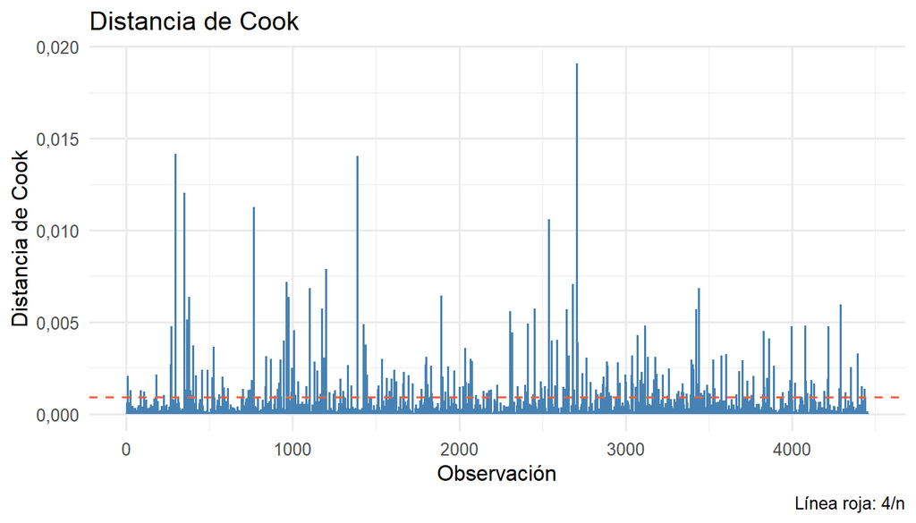

```r
ggplot(infl, aes(id, cook)) + geom_segment(aes(xend = id, yend = 0), color = "steelblue") +
  geom_hline(yintercept = 4 / n, color = "tomato", linetype = "dashed") +
  labs(title = "Distancia de Cook", x = "Observación", y = "Distancia de Cook", caption = "Línea roja: 4/n")
```

Ninguna observación tiene una distancia de Cook cercana a 1 (el máximo es 0,019): **ningún caso individual domina el modelo**. Hay 81 con residuo studentizado mayor a 3 (1,8 %), casi todos con monto muy inferior al esperado, y 260 con Cook > 4/n. Comparamos los coeficientes con y sin los casos influyentes:

**Ver código**

```r
fuera <- abs(infl$rstud) > 3 | infl$cook > 4 / n
m_sin <- lm(f_pol, data = cred[!fuera, ])
round(cbind(Con_todos = coef(m_pol), Sin_influyentes = coef(m_sin)), 4)
```

```
                 Con_todos Sin_influyentes
(Intercept)         0,2253          0,1524
log_Price           0,7402          0,7664
Time                0,0306          0,0325
I(Time^2)          -0,0002         -0,0002
Seniority          -0,0017         -0,0015
Recordssi           0,0406          0,0535
Jobindependiente    0,0859          0,0684
Jobmedio_tiempo     0,0563          0,0640
Jobotro             0,0522          0,0629
log_Income          0,0680          0,0477
Tiene_deudasi      -0,0383         -0,0215
```

## 4.5 Incumplimiento de supuestos: bootstrap

Como la heterocedasticidad y la no normalidad persisten, los intervalos clásicos del `summary` podrían no ser confiables. El **bootstrap** (1000 remuestras de filas) da intervalos de confianza que **no requieren normalidad ni varianza constante**:

**Ver código**

```r
set.seed(2024)
bt <- boot(cred, function(d, i) coef(lm(f_pol, data = d[i, ])), R = 1000)
ci_boot <- t(sapply(seq_along(coef(m_pol)), function(j) boot.ci(bt, type = "perc", index = j)$percent[4:5]))
ci_cl <- confint(m_pol)
ancho_rel <- median((ci_boot[, 2] - ci_boot[, 1]) / (ci_cl[, 2] - ci_cl[, 1]))
ib <- function(nm) paste0("[", fmt(ci_boot[names(coef(m_pol)) == nm, 1]), "; ", fmt(ci_boot[names(coef(m_pol)) == nm, 2]), "]")
```

Los intervalos bootstrap tienen, en mediana, 1,00 veces el ancho de los clásicos (prácticamente el mismo): la inferencia de MCO es confiable pese a los supuestos incumplidos (además, con n = 4454 la falta de normalidad afecta poco). En el modelo final usamos los intervalos bootstrap.

# 5 Modelo lineal final e interpretación

## 5.1 Ecuación

**Ver código**

```r
cf <- coef(m_pol)
# Formato para LaTeX: coma decimal sin espacio ({,}) y signo explícito
tx <- function(x, d) gsub(".", "{,}", formatC(abs(x), format = "f", digits = d, decimal.mark = "."), fixed = TRUE)
sg <- function(x, d) paste0(ifelse(x < 0, "-", "+"), " ", tx(x, d))
```

$$\widehat{\log(\text{Monto})} = 0{,}225 + 0{,}740\,\log(\text{Precio}) + 0{,}0306\,\text{Plazo} - 0{,}00021\,\text{Plazo}^2 - 0{,}0017\,\text{Antigüedad} + 0{,}041\,\text{Antecedentes(sí)} + 0{,}086\,\text{Indep.} + 0{,}056\,\text{Medio tiempo} + 0{,}052\,\text{Otro empleo} + 0{,}068\,\log(\text{Ingreso}) - 0{,}038\,\text{Deuda(sí)}$$

## 5.2 Tabla de coeficientes

**Ver código**

```r
tab_fin <- data.frame(Coeficiente = rownames(summary(m_pol)$coef), Estimación = fmt(coef(m_pol)),
  IC95_inf = fmt(ci_boot[, 1]), IC95_sup = fmt(ci_boot[, 2]),
  p_valor = format.pval(summary(m_pol)$coef[, 4], digits = 2, eps = 1e-4), row.names = NULL)
knitr::kable(tab_fin, caption = "Modelo lineal final: estimaciones con IC bootstrap al 95 %")
```

Modelo lineal final: estimaciones con IC bootstrap al 95 %

| Coeficiente | Estimación | IC95_inf | IC95_sup | p_valor |
| --- | --- | --- | --- | --- |
| (Intercept) | 0,225 | 0,0391 | 0,421 | 0,01291 |
| log_Price | 0,740 | 0,716 | 0,764 | < 1e-04 |
| Time | 0,0306 | 0,0262 | 0,0353 | < 1e-04 |
| I(Time^2) | -0,000206 | -0,000261 | -0,000156 | < 1e-04 |
| Seniority | -0,00171 | -0,00287 | -0,000622 | 0,00297 |
| Recordssi | 0,0406 | 0,0168 | 0,0619 | 0,00058 |
| Jobindependiente | 0,0859 | 0,0639 | 0,108 | < 1e-04 |
| Jobmedio_tiempo | 0,0563 | 0,0280 | 0,0829 | 0,00035 |
| Jobotro | 0,0522 | 0,00938 | 0,0910 | 0,02917 |
| log_Income | 0,0680 | 0,0481 | 0,0853 | < 1e-04 |
| Tiene_deudasi | -0,0383 | -0,0616 | -0,0163 | 0,00127 |

R² = 0,662, **R² ajustado = 0,661**, error estándar residual = 0,297.

## 5.3 Interpretación de cada coeficiente

Como la respuesta está en logaritmos, el coeficiente $b$ de una variable *sin* log se interpreta como un cambio de $100\,(e^{b}-1)$ % en el monto por cada unidad más; para una variable *en* logaritmo, $b$ es una **elasticidad** (cambio % del monto por cada 1 % de cambio en la variable). Siempre “manteniendo constantes las demás variables”.

- **Precio del bien (`log_Price`, 0,74):** un bien 10 % más caro aumenta el monto pedido alrededor de 7,3 %. Como el coeficiente es menor que 1, al subir el precio la persona financia *proporcionalmente* un poco menos. Es el efecto más importante.
- **Plazo (`Time` y `Time²`):** más plazo implica más monto, pero con rendimientos decrecientes (término cuadrático negativo). Respecto de un préstamo a 12 meses, el monto pedido es en promedio:

**Ver código**

```r
plazo <- c(24, 36, 48, 60)
data.frame(Plazo = paste(plazo, "meses"),
           Cambio_respecto_a_12_meses = paste0("+", pct(cf["Time"] * (plazo - 12) + cf["I(Time^2)"] * (plazo^2 - 144)), " %")) |>
  knitr::kable()
```

| Plazo | Cambio_respecto_a_12_meses |
| --- | --- |
| 24 meses | +32 % |
| 36 meses | +64,2 % |
| 48 meses | +92,5 % |
| 60 meses | +112,6 % |

- **Antigüedad laboral (`Seniority`, -0,0017):** cada año más en el trabajo actual se asocia con un monto 0,2 % **menor** (10 años más: 1,7 % menos). Efecto chico pero distinguible de cero.
- **Antecedentes (`Recordssi`, 0,041):** quienes tienen antecedentes piden en promedio 4,1 % **más**.
- **Tipo de empleo (referencia: fijo):** los **independientes** piden 9 % más, los de **medio tiempo** 5,8 % más y la categoría **otro** 5,4 % más. “Otro” es un grupo chico (171 personas) y su efecto es el menos firme (IC bootstrap de su coeficiente: [0,00938; 0,0910], el más cercano a cero).
- **Ingreso (`log_Income`, 0,068):** un ingreso 10 % mayor se asocia con un monto 0,7 % mayor: efecto real pero modesto.
- **Deuda previa (`Tiene_deudasi`, -0,038):** quienes ya tienen deudas piden en promedio 3,8 % **menos**.
- **Intercepto (0,23):** corresponde a un caso de referencia (precio 1, plazo 0…) fuera del rango de los datos; no tiene interpretación práctica.

## 5.4 Calidad del modelo y conclusión

El modelo explica el **66,1 % de la variabilidad** del log-monto (R² ajustado) y el error típico de predicción es de aproximadamente 35 % del monto. **Conclusión para el objetivo:** el monto pedido lo determinan sobre todo las condiciones del préstamo: el **precio del bien** (más caro, más se pide) y el **plazo** (más largo, más se pide, con rendimientos decrecientes). El perfil del solicitante tiene efectos reales pero pequeños: piden algo más quienes tienen más ingreso, trabajan de forma independiente o a medio tiempo o tienen antecedentes, y algo menos quienes tienen más antigüedad o ya tienen deudas. Edad, estado civil, gastos, patrimonio, vivienda e `Ingreso_faltante` no aportan una vez considerado lo anterior. Como cautela, hay un grupo que pide mucho menos de lo que predice el modelo (financia una parte pequeña del bien), por motivos que no están en los datos.

# 6 Regresión logística: ¿quién termina siendo mal pagador?

**Respuesta:** `Status` (1 = **malo**, 0 = bueno). El modelo estima la probabilidad de ser mal pagador y los *odds ratios* se interpretan como cambios en el riesgo. Aquí **sí** usamos `Pct_fin` como predictora (la respuesta ya no es el monto) y `Ingreso_faltante` como candidata.

## 6.1 Partición en entrenamiento y prueba, antes de imputar

Para evaluar honestamente la capacidad predictiva ajustamos todo con el **75 % de los datos (entrenamiento)** y evaluamos con el **25 % restante (prueba)**. La partición es estratificada (conserva la proporción de malos pagadores).

**Fuga de información (*data leakage*)** es cuando el modelo “ve”, directa o indirectamente, información del conjunto de prueba durante su construcción; entonces la evaluación resulta demasiado optimista. Por eso la partición se hace **antes de imputar**, y:

- `train` se imputa con kNN usando **solo filas de `train`**.
- `test` se imputa usando **solo filas de `train` como donantes**: cada fila de `test` con faltantes se agrega sola al `train` ya imputado, así que sus únicos vecinos posibles son filas de `train` (función `imputar_con_train`).
- La selección de variables, el punto de corte y todo ajuste se hacen **solo con `train`**; `test` se usa **una sola vez, al final**.

**Ver código**

```r
set.seed(2024)
idx <- createDataPartition(base$Status, p = 0.75, list = FALSE)
tr_raw <- base[idx, ]
te_raw <- base[-idx, ]

train <- imputar_knn(tr_raw)                  # donantes: solo train
test <- imputar_con_train(te_raw, train)      # donantes: solo train
train <- transformar(derivar(train))
test <- transformar(derivar(test))

data.frame(Conjunto = c("Entrenamiento", "Prueba"), Filas = c(nrow(train), nrow(test)),
           Porc_malos = round(100 * c(mean(train$Status == "malo"), mean(test$Status == "malo")), 1),
           Filas_con_NA_antes = c(sum(!complete.cases(tr_raw)), sum(!complete.cases(te_raw))),
           NA_despues = c(sum(is.na(train)), sum(is.na(test)))) |> knitr::kable()
```

| Conjunto | Filas | Porc_malos | Filas_con_NA_antes | NA_despues |
| --- | --- | --- | --- | --- |
| Entrenamiento | 3341 | 28,2 | 312 | 0 |
| Prueba | 1113 | 28,1 | 103 | 0 |

## 6.2 Modelo inicial y selección de variables (solo entrenamiento)

**Ver código**

```r
f_log <- Status ~ log_Seniority + Age + Marital + Records + Job + Expenses + log_Income + log_Assets +
  Tiene_deuda + Home + Time + log_Price + Pct_fin + Ingreso_faltante
g_full <- glm(f_log, family = binomial, data = train)
summary(g_full)
```

```
Call:
glm(formula = f_log, family = binomial, data = train)

Coefficients:
                  Estimate Std. Error z value Pr(>|z|)
(Intercept)      -3,562460   1,027885  -3,466 0,000529 ***
log_Seniority    -0,581949   0,057808 -10,067  < 2e-16 ***
Age               0,008570   0,005751   1,490 0,136188
Maritalsoltero    0,338627   0,149996   2,258 0,023973 *
Maritalotro       0,970632   0,211566   4,588 4,48e-06 ***
Recordssi         1,828174   0,120690  15,148  < 2e-16 ***
Jobindependiente  0,301314   0,135599   2,222 0,026277 *
Jobmedio_tiempo   1,311286   0,156242   8,393  < 2e-16 ***
Jobotro           0,358575   0,242392   1,479 0,139055
Expenses          0,017873   0,003078   5,807 6,36e-09 ***
log_Income       -1,187329   0,110509 -10,744  < 2e-16 ***
log_Assets       -0,107855   0,019030  -5,668 1,45e-08 ***
Tiene_deudasi     0,677838   0,146406   4,630 3,66e-06 ***
Homealquila       0,253352   0,187144   1,354 0,175806
Homepadres       -0,251854   0,197526  -1,275 0,202294
Homeprivada       0,788822   0,199458   3,955 7,66e-05 ***
Homeotra          0,707187   0,213978   3,305 0,000950 ***
Time             -0,004035   0,004366  -0,924 0,355319
log_Price         0,660622   0,133697   4,941 7,76e-07 ***
Pct_fin           0,036331   0,003260  11,145  < 2e-16 ***
Ingreso_faltante  1,386042   0,179024   7,742 9,77e-15 ***
---
Signif. codes:  0 '***' 0,001 '**' 0,01 '*' 0,05 '.' 0,1 ' ' 1

(Dispersion parameter for binomial family taken to be 1)

    Null deviance: 3972,5  on 3340  degrees of freedom
Residual deviance: 2766,9  on 3320  degrees of freedom
AIC: 2808,9

Number of Fisher Scoring iterations: 5
```

**Ver código**

```r
vif_log <- vif(g_full)
vif_log
```

```
                     GVIF Df GVIF^(1/(2*Df))
log_Seniority    1,416000  1        1,189958
Age              1,698416  1        1,303233
Marital          1,993814  2        1,188287
Records          1,106877  1        1,052082
Job              2,022587  3        1,124565
Expenses         1,715537  1        1,309785
log_Income       1,261778  1        1,123289
log_Assets       3,008633  1        1,734541
Tiene_deuda      1,350497  1        1,162109
Home             4,173634  4        1,195540
Time             1,588052  1        1,260179
log_Price        1,412132  1        1,188332
Pct_fin          1,424786  1        1,193644
Ingreso_faltante 1,335117  1        1,155473
```

Usamos `log_Seniority = log(1 + Seniority)` en lugar de `Seniority` (se justifica más abajo). Los GVIF ajustados (`GVIF^(1/(2*Df))`) son todos menores a 1,8: no hay multicolinealidad problemática. Seleccionamos con `stepAIC` (AIC y BIC):

**Ver código**

```r
g_aic <- stepAIC(g_full, direction = "both", trace = 0)
g_bic <- stepAIC(g_full, direction = "both", k = log(nrow(train)), trace = 0)

# Modelo elegido por BIC, escrito explícitamente (se verifica que coincide con el que devolvió stepAIC)
f_bic_log <- Status ~ log_Seniority + Marital + Records + Job + Expenses + log_Income + log_Assets +
  Tiene_deuda + Home + log_Price + Pct_fin + Ingreso_faltante
n_var_log <- function(f) length(strsplit(as.character(f)[3], " + ", fixed = TRUE)[[1]])
stopifnot(setequal(names(coef(glm(f_bic_log, family = binomial, data = train))), names(coef(g_bic))),
          "Age" %in% names(coef(g_aic)), !("Time" %in% names(coef(g_aic))), !("Age" %in% names(coef(g_bic))),
          "Ingreso_faltante" %in% c(names(coef(g_aic)), names(coef(g_bic))))

tab_mod <- data.frame(Modelo = c("Completo (14 candidatas)", "stepAIC", "stepBIC"),
                      Coeficientes = c(length(coef(g_full)), length(coef(g_aic)), length(coef(g_bic))),
                      AIC = round(c(aic(g_full), aic(g_aic), aic(g_bic)), 1),
                      BIC = round(c(bic(g_full), bic(g_aic), bic(g_bic)), 1))
knitr::kable(tab_mod, caption = "Modelos candidatos (calculados con el conjunto de entrenamiento)")
```

Modelos candidatos (calculados con el conjunto de entrenamiento)

| Modelo | Coeficientes | AIC | BIC |
| --- | --- | --- | --- |
| Completo (14 candidatas) | 21 | 2808,9 | 2937,3 |
| stepAIC | 20 | 2807,7 | 2930,0 |
| stepBIC | 19 | 2808,0 | 2924,1 |

**Ver código**

```r
lr_edad <- lrtest(g_bic, g_aic)
lr_edad
```

|  | #Df | LogLik | Df | Chisq | Pr(>Chisq) |
| --- | --- | --- | --- | --- | --- |
| 1 | 19 | -1384,976 | NA | NA | NA |
| 2 | 20 | -1383,857 | 1 | 2,238062 | 0,1346497 |

- **BIC descarta** `Age` y `Time`. **AIC descarta** solo `Time`. `Ingreso_faltante` **queda en ambos**.
- El **test de razón de verosimilitud** entre el modelo BIC y el AIC (¿mejoran el ajuste las variables que solo conserva el AIC?) da p = 0,13: no mejoran el ajuste de forma significativa. Con muchos datos casi cualquier variable termina “significativa”, así que elegimos por **parsimonia: modelo BIC**.

**Ver código**

```r
g_fin <- g_bic
g_sin_ing <- glm(Status ~ log_Seniority + Marital + Records + Job + Expenses + log_Income + log_Assets +
                   Tiene_deuda + Home + log_Price + Pct_fin, family = binomial, data = train)  # modelo final sin Ingreso_faltante
lr_ing <- lrtest(g_sin_ing, g_fin)
lrtest(g_fin, glm(Status ~ 1, family = binomial, data = train))   # modelo final vs. solo intercepto
```

|  | #Df | LogLik | Df | Chisq | Pr(>Chisq) |
| --- | --- | --- | --- | --- | --- |
| 1 | 19 | -1384,976 | NA | NA | NA |
| 2 | 1 | -1986,248 | -18 | 1202,543 | 3,190793e-244 |

El modelo final es **muy superior al modelo sin predictoras**. Son 18 coeficientes (sin el intercepto) para 12 variables. Agregar `Ingreso_faltante` mejora el ajuste de forma contundente (razón de verosimilitud contra el mismo modelo sin ella: p <0,001).

**¿Por qué `log(1 + Seniority)`?** Al revisar la bondad de ajuste con `Seniority` en su escala original, Hosmer-Lemeshow (H0: el ajuste es bueno) detectaba un desajuste. El efecto de la antigüedad no es lineal en el log-odds: importa mucho pasar de 0 a unos pocos años y poco pasar de 20 a 25. Con el logaritmo (la variable tiene asimetría 1,39 y 401 ceros, igual que `Assets`) el ajuste mejora:

**Ver código**

```r
f_sen_lin <- Status ~ Seniority + Marital + Records + Job + Expenses + log_Income + log_Assets +
  Tiene_deuda + Home + log_Price + Pct_fin + Ingreso_faltante     # igual al modelo final, pero con Seniority lineal
g_sen_lin <- glm(f_sen_lin, family = binomial, data = train)
y_tr <- as.integer(train$Status == "malo")
hl_lin <- hoslem.test(y_tr, fitted.values(g_sen_lin), g = 10)
hl <- hoslem.test(y_tr, fitted.values(g_fin), g = 10)
data.frame(Version = c("Seniority lineal", "log(1 + Seniority) (final)"),
           AIC = round(c(aic(g_sen_lin), aic(g_fin)), 1), BIC = round(c(bic(g_sen_lin), bic(g_fin)), 1),
           p_Hosmer_Lemeshow = round(c(hl_lin$p.value, hl$p.value), 3)) |> knitr::kable()
```

| Version | AIC | BIC | p_Hosmer_Lemeshow |
| --- | --- | --- | --- |
| Seniority lineal | 2817,8 | 2934,0 | 0,024 |
| log(1 + Seniority) (final) | 2808,0 | 2924,1 | 0,550 |

**Hosmer-Lemeshow** divide a los solicitantes en 10 grupos según su riesgo predicho y compara los malos pagadores esperados con los observados en cada grupo. Con `Seniority` lineal p = 0,024 (rechaza: hay desajuste); con el logaritmo p = 0,55 (no rechaza: no hay evidencia de mal ajuste; no rechazar no prueba que el ajuste sea perfecto). Esta evaluación se hizo solo con `train`.

## 6.3 Modelo final: odds ratios

**Ver código**

```r
or_tab <- exp(cbind(OR = coef(g_fin), suppressMessages(confint(g_fin))))
colnames(or_tab) <- c("OR", "IC95_inf", "IC95_sup")
knitr::kable(data.frame(Variable = rownames(or_tab), OR = round(or_tab[, 1], 3), IC95_inf = round(or_tab[, 2], 3),
                        IC95_sup = round(or_tab[, 3], 3),
                        p_valor = format.pval(summary(g_fin)$coef[, 4], digits = 2, eps = 1e-4), row.names = NULL),
             caption = "Odds ratios con IC al 95 % (modelo final, entrenamiento)")
```

Odds ratios con IC al 95 % (modelo final, entrenamiento)

| Variable | OR | IC95_inf | IC95_sup | p_valor |
| --- | --- | --- | --- | --- |
| (Intercept) | 0,048 | 0,007 | 0,319 | 0,0018 |
| log_Seniority | 0,572 | 0,513 | 0,637 | <1e-04 |
| Maritalsoltero | 1,341 | 1,008 | 1,782 | 0,0433 |
| Maritalotro | 2,673 | 1,765 | 4,035 | <1e-04 |
| Recordssi | 6,292 | 4,976 | 7,982 | <1e-04 |
| Jobindependiente | 1,405 | 1,080 | 1,822 | 0,0108 |
| Jobmedio_tiempo | 3,724 | 2,746 | 5,065 | <1e-04 |
| Jobotro | 1,595 | 1,006 | 2,516 | 0,0456 |
| Expenses | 1,018 | 1,012 | 1,025 | <1e-04 |
| log_Income | 0,310 | 0,249 | 0,383 | <1e-04 |
| log_Assets | 0,901 | 0,868 | 0,935 | <1e-04 |
| Tiene_deudasi | 1,864 | 1,408 | 2,465 | <1e-04 |
| Homealquila | 1,277 | 0,883 | 1,840 | 0,1911 |
| Homepadres | 0,751 | 0,510 | 1,099 | 0,1437 |
| Homeprivada | 2,183 | 1,473 | 3,219 | <1e-04 |
| Homeotra | 2,015 | 1,322 | 3,057 | 0,0010 |
| log_Price | 1,826 | 1,447 | 2,312 | <1e-04 |
| Pct_fin | 1,035 | 1,030 | 1,041 | <1e-04 |
| Ingreso_faltante | 4,006 | 2,827 | 5,703 | <1e-04 |

**Ver código**

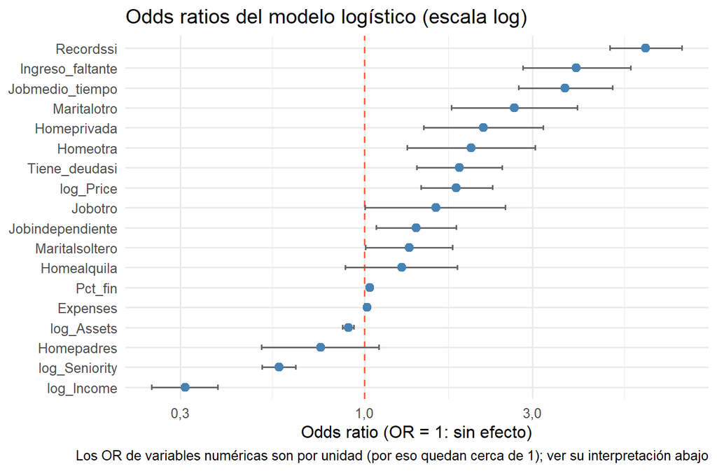

```r
or_plot <- data.frame(Variable = rownames(or_tab), or_tab, row.names = NULL) |> dplyr::filter(Variable != "(Intercept)")
ggplot(or_plot, aes(x = OR, y = reorder(Variable, OR))) +
  geom_vline(xintercept = 1, linetype = "dashed", color = "tomato") +
  geom_errorbarh(aes(xmin = IC95_inf, xmax = IC95_sup), height = .25, color = "grey40") +
  geom_point(color = "steelblue", size = 2.5) + scale_x_log10() +
  labs(title = "Odds ratios del modelo logístico (escala log)", x = "Odds ratio (OR = 1: sin efecto)", y = NULL,
       caption = "Los OR de variables numéricas son por unidad (por eso quedan cerca de 1); ver su interpretación abajo")
```

### 6.3.1 Interpretación de los odds ratios

*Odds* (chances) = probabilidad de ser malo / probabilidad de ser bueno. Un **OR mayor a 1 aumenta** las chances de ser mal pagador y uno **menor a 1 las reduce**; si el intervalo incluye al 1, el efecto no se distingue de cero. Siempre “manteniendo constantes las demás variables”.

**Ver código**

```r
b <- coef(g_fin); ci_or <- exp(suppressMessages(confint(g_fin)))
OR <- function(nm) round(exp(b[nm]), 2)
incl1 <- function(nm) ci_or[nm, 1] < 1 & ci_or[nm, 2] > 1
```

- **Antecedentes (`Recordssi`, OR = 6,29):** tener antecedentes **multiplica por 6,29** las chances de ser mal pagador. Es el factor de riesgo más fuerte.
- **Ingreso no informado (`Ingreso_faltante`, OR = 4,01, IC 2,83 a 5,7):** quienes **no informaron su ingreso** tienen chances 4,01 veces mayores de ser malos pagadores que quienes sí lo informaron, **a igualdad de las demás variables** (incluido el ingreso imputado); el aporte de la variable es significativo (razón de verosimilitud, p <0,001). No es un efecto causal: es una **señal** de cómo se cargó la solicitud, coherente con que la ausencia del dato no es azarosa.
- **Tipo de empleo (referencia: fijo):** medio tiempo multiplica las chances por 3,72, independiente por 1,4 (efecto significativo, aunque mucho menor que el de medio tiempo) y otro por 1,6.
- **Antigüedad (`log_Seniority`, OR = 0,57 por unidad de log):** al estar en logaritmo, lo que importa es **cuánto se multiplica** la antigüedad (más precisamente `1 + años`): duplicarla (por ejemplo, pasar de 1 a 3 años, o de 3 a 7) multiplica las chances por 0,68, es decir, las **reduce un 32 %**. Más antigüedad protege, sobre todo en los primeros años.
- **Ingreso (`log_Income`):** duplicar el ingreso multiplica las chances por 0,44 (las **reduce a menos de la mitad**); un ingreso 10 % mayor, por 0,89.
- **Activos (`log_Assets`):** multiplicar por 10 el patrimonio multiplica las chances por 0,79 (las reduce 21 %).
- **Porcentaje financiado (`Pct_fin`, OR = 1,04):** cada punto más del precio que se financia aumenta las chances 3,5 %; **10 puntos más** las multiplican por 1,42.
- **Precio (`log_Price`):** con el mismo % financiado, un bien 10 % más caro aumenta las chances 5,9 %.
- **Gastos (`Expenses`, OR = 1,02):** 10 unidades más de gastos multiplican las chances por 1,2.
- **Deuda previa (`Tiene_deudasi`, OR = 1,86):** tener deudas **aumenta 86 %** las chances. En el exploratorio, la deuda sola casi no marcaba diferencia; el efecto aparece al **controlar por las demás variables** (quienes tienen deuda suelen tener más ingreso y patrimonio, y eso lo enmascaraba).
- **Estado civil (referencia: casado):** soltero OR = 1,34 y otro OR = 2,67: más riesgo que los casados.
- **Vivienda (referencia: propia):** privada (2,18) y otra (2,01) duplican aproximadamente las chances; alquilar (1,28) y vivir con los padres (0,75) no se distinguen de ser propietario (sus intervalos incluyen al 1).

## 6.4 Capacidad predictiva en el conjunto de prueba

A partir de acá usamos `test`, **una sola vez**, con el modelo y el punto de corte ya definidos con `train`.

### 6.4.1 Curva ROC y AUC

**Ver código**

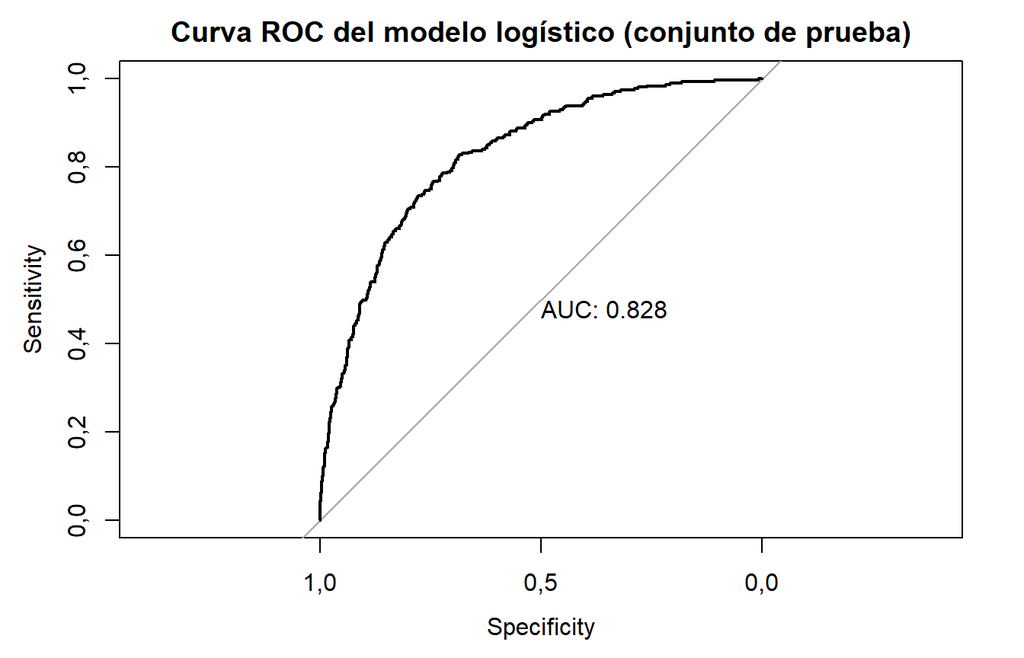

```r
p_test <- predict(g_fin, newdata = test, type = "response")
roc_test <- roc(test$Status, p_test, levels = c("bueno", "malo"), direction = "<", quiet = TRUE)
roc_train <- roc(train$Status, fitted.values(g_fin), levels = c("bueno", "malo"), direction = "<", quiet = TRUE)
plot(roc_test, print.auc = TRUE, main = "Curva ROC del modelo logístico (conjunto de prueba)")
```

**Ver código**

```r
auc_te <- as.numeric(roc_test$auc); auc_tr <- as.numeric(roc_train$auc)
```

El **AUC en prueba es 0,828**: si se toma al azar un mal pagador y un buen pagador, el modelo asigna mayor riesgo al mal pagador en ~83 % de los casos (discriminación buena). En entrenamiento es 0,854: la diferencia es chica, **no hay sobreajuste importante**.

### 6.4.2 Elección del punto de corte

El corte “por defecto” de 0,5 funciona mal cuando hay pocos eventos (28 % de malos): muy pocos solicitantes lo superan y el modelo clasifica como “bueno” a muchos malos pagadores. Además, **otorgar un crédito que no se paga cuesta más que rechazar a un buen pagador**. Por eso elegimos el corte con `coords(roc, "best", ret = "threshold")` (Unidad 5): **el corte que maximiza a la vez la sensibilidad y la especificidad**. Ese criterio se conoce como **índice de Youden** (sensibilidad + especificidad − 1). Lo calculamos **solo con `train`**:

**Ver código**

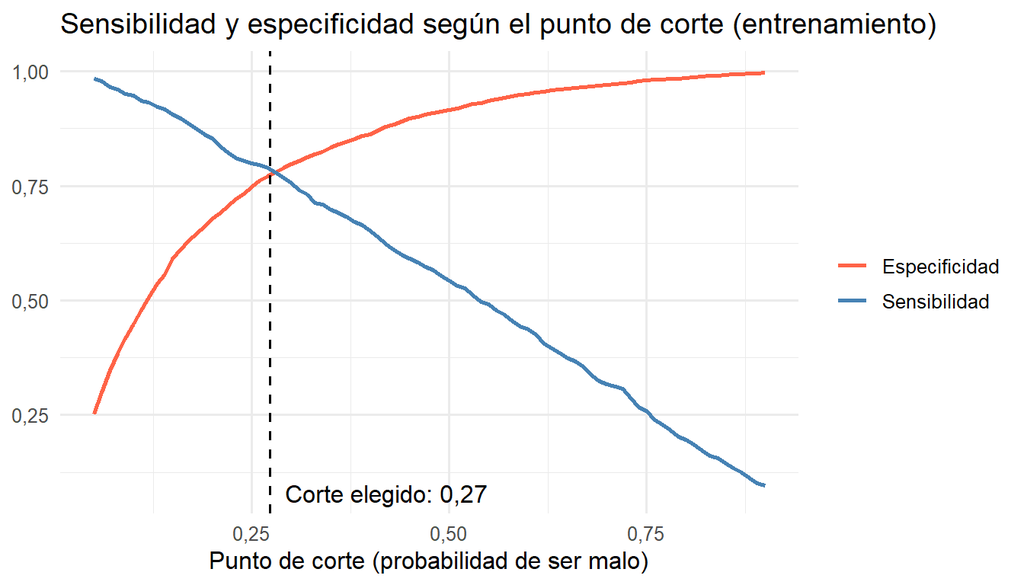

```r
corte <- coords(roc_train, "best", ret = "threshold")[1, 1]
cortes <- seq(0.05, 0.9, by = 0.01)
curva <- data.frame(corte = cortes,
  Sensibilidad = sapply(cortes, function(k) mean(fitted.values(g_fin)[train$Status == "malo"] > k)),
  Especificidad = sapply(cortes, function(k) mean(fitted.values(g_fin)[train$Status == "bueno"] <= k)))
curva |> tidyr::pivot_longer(-corte, names_to = "Medida", values_to = "valor") |>
  ggplot(aes(corte, valor, color = Medida)) + geom_line(linewidth = 1) + geom_vline(xintercept = corte, linetype = "dashed") +
  annotate("text", x = corte + 0.02, y = 0.08, label = paste("Corte elegido:", round(corte, 2)), hjust = 0) +
  scale_color_manual(values = c("tomato", "steelblue")) +
  labs(title = "Sensibilidad y especificidad según el punto de corte (entrenamiento)",
       x = "Punto de corte (probabilidad de ser malo)", y = NULL, color = NULL)
```

El corte es **0,27** (cerca de la tasa base de malos): se clasifica como “malo” a quien tenga una probabilidad predicha mayor a ese valor.

### 6.4.3 Matriz de confusión y métricas

**Ver código**

```r
evaluar <- function(prob, y, k) {
  pred <- factor(ifelse(prob > k, "malo", "bueno"), levels = c("bueno", "malo"))
  confusionMatrix(pred, y, positive = "malo", mode = "everything")
}
cm_05 <- evaluar(p_test, test$Status, 0.5)
cm_k <- evaluar(p_test, test$Status, corte)
cm_k$table
```

```
          Reference
Prediction bueno malo
     bueno   605   79
     malo    195  234
```

**Ver código**

```r
met <- function(cm) c(Exactitud = unname(cm$overall["Accuracy"]), Sensibilidad = unname(cm$byClass["Sensitivity"]),
                      Especificidad = unname(cm$byClass["Specificity"]), VPP = unname(cm$byClass["Pos Pred Value"]),
                      VPN = unname(cm$byClass["Neg Pred Value"]), F1 = unname(cm$byClass["F1"]))
m05 <- met(cm_05); mk <- met(cm_k)
tab_met <- data.frame(Métrica = names(mk), `Corte 0,5` = round(m05, 3), `Corte elegido` = round(mk, 3),
                      check.names = FALSE, row.names = NULL)
names(tab_met)[3] <- paste0("Corte elegido (", round(corte, 2), ")")
knitr::kable(tab_met, caption = "Métricas en el conjunto de prueba (evento positivo = malo)")
```

Métricas en el conjunto de prueba (evento positivo = malo)

| Métrica | Corte 0,5 | Corte elegido (0,27) |
| --- | --- | --- |
| Exactitud | 0,785 | 0,754 |
| Sensibilidad | 0,505 | 0,748 |
| Especificidad | 0,895 | 0,756 |
| VPP | 0,653 | 0,545 |
| VPN | 0,822 | 0,885 |
| F1 | 0,569 | 0,631 |

Con el corte de 0,5 el modelo detecta solo el **50 %** de los malos pagadores. Con el corte elegido (0,27):

- **Sensibilidad 75 %:** de cada 100 malos pagadores, el modelo detecta unos 75.
- **Especificidad 76 %:** de cada 100 buenos pagadores, aprueba correctamente a unos 76.
- **VPP (valor predictivo positivo) 55 %:** de los que el modelo marca como riesgosos, esa proporción realmente lo es (el resto son buenos pagadores rechazados por prudencia).
- **VPN (valor predictivo negativo) 88 %:** de los que considera seguros, esa proporción efectivamente paga.
- **Exactitud 75 %,** menor que con 0,5 (79 %), pero la exactitud **engaña** con clases desbalanceadas: clasificar a todos como “buenos” daría 72 % de exactitud sin detectar a ningún mal pagador. Por eso priorizamos sensibilidad y F1 (0,57 → 0,63).

# 7 Síntesis y limitaciones

## 7.1 Resultados principales

- **Datos:** 4454 solicitantes. Se recodificaron categorías pequeñas, se estudió el **mecanismo de los faltantes** (`Income`, 8,6 %: **no es MCAR**, plausiblemente MAR), se imputó con **kNN** y se conservó la señal con `Ingreso_faltante`. Se crearon variables derivadas (`Pct_fin`, `Tiene_deuda`), se aplicó logaritmo a las variables monetarias asimétricas y no se eliminaron atípicos (son casos reales).
- **Monto pedido (lineal, R² ajustado 0,66):** depende sobre todo del **precio del bien** (elasticidad 0,74) y del **plazo** (con rendimientos decrecientes). El perfil del solicitante tiene efectos reales pero pequeños (entre 3,8 y 9 %).
- **Supuestos del lineal:** `Time` no era lineal (se agregó `Time²`); persisten heterocedasticidad y residuos asimétricos por una cola de montos muy bajos (un rasgo de los datos), y el bootstrap confirma que la inferencia es confiable.
- **Mal pagador (logística):** el riesgo sube con **antecedentes** (OR 6,29), **empleo de medio tiempo** (OR 3,72), **ingreso no informado** (OR 4,01), mayor % financiado, gastos y deudas; y baja con **más ingreso, antigüedad y patrimonio**.
- **Capacidad predictiva:** AUC 0,828 en prueba, sin fuga de información. Con corte 0,27: sensibilidad 75 %, especificidad 76 %.

## 7.2 Limitaciones

- **Mecanismo de los faltantes:** demostramos que no es MCAR y es plausible MAR, pero **MNAR no puede verificarse** con estos datos (por ejemplo, si quienes tienen ingresos muy bajos lo ocultan más). Además, kNN completa cada ingreso faltante con la mediana de sus 5 vecinos más parecidos, y las medianas varían menos que los datos reales, por lo que los ingresos imputados tienen menos dispersión que los observados. `Ingreso_faltante` es una señal útil para predecir, pero no explica *por qué* faltaba el dato.
- **Imputación en el lineal:** la regresión lineal se ajusta con todos los datos y no tiene conjunto de prueba, así que imputar con todas las filas no genera fuga de información; en la logística sí se evitó (imputación de `test` con donantes de `train`).
- **Falta de contexto:** la fuente no informa moneda, país, año ni cómo se define “mal pagador” o “antecedentes”. Los resultados describen esta muestra.
- **Relación no causal:** son asociaciones observacionales.
- **Modelo lineal:** residuos asimétricos y monto acotado por el precio; modelar la *proporción financiada* podría ser más natural.
- **Modelo logístico:** clases algo desbalanceadas (28 % de malos); una sola partición; sin interacciones; el punto de corte depende de costos que asumimos.
- **Variables con efectos pequeños descartadas por BIC** podrían ser relevantes para otros objetivos.